# OPIHI Sampling Effort & Data Quality

OCN 682 / MBIO 612 AI Data Sprint — Question B

Author

Team B: Manōʻike, Gabby, Tim, Yang An

Published

November 10, 2026

## 1. Question and metrics

**Question B:** How does sampling effort (survey dates, transects, quadrats) differ among OPIHI sites and years, which site-years are most complete, and how much data coverage remains as stricter quality filters are applied?

| Metric | Definition |
| --- | --- |
| Survey (observation unit) | One field trip: one date × one site × one school/team group |
| Planned quadrats | `n_transects_recorded × quad_per_transect_recorded`, from the trip metadata |
| Observed quadrats | Quadrats that actually have data in the raw sheets |
| Completeness | observed ÷ planned quadrats |
| Complete survey | Completeness ≥ 0.8, quadrat data present, key metadata present and plausible |
| Site-year coverage tier | 2+ complete surveys / 1 complete survey / none |

## 2. Data inventory

**Scope:** All 20 workbooks were inventoried. Surveys from 2004–2008, 2016–2020 and 2024–2026 that have a date and a site are included. There are no files for 2009–2015 or 2021–2023.

```r
surveys |>
  count(data_era, name = "surveys") |>
  kable(col.names = c("Source", "Surveys in master")) |>
  kable_styling(full_width = FALSE, bootstrap_options = c("striped", "condensed"))
```

| Source | Surveys in master |
| --- | --- |
| 2004-2020 compiled sheet only | 20 |
| 2004-2020 yearly workbooks | 231 |
| 2024-2026 longitudinal sheets | 22 |
| 2026 class worksheet | 2 |

## 3. Cleaning decisions

Raw files in `Data/AI data` are never edited. Every rule below is coded in `scripts/01_build_master.R`, and every removed record is written to a log.

1. **Different layouts → one schema.** The 2004–2020 files store one trip per column block. The 2024–2026 files store one quadrat per row. The 2026 Waipuʻilani class sheet pools 11 quadrats × 25 points per group. Each layout has its own importer (`scripts/Functions/import_wide.R`, `scripts/Function/import_long.R`).
2. **Duplicates.** 430 duplicate records were removed (387 exact copies and 43 near-copies in *Copy of OPIHI 2024 datasheet*, where taxon columns were renamed). The compiled 2004–2020 sheet (*OPIHI Data – Reformated*) repeats the yearly files. It is used only to cross-check counts and to add the 20 trips that have no raw yearly block.
3. **Site names.** Site labels were normalised by removing ʻokina and macrons and lower-casing, then mapped with `Outputs/Site Lookup/lookup/site_lookup.csv`, which prefers Hawaiian names (Diamond Head → Lēʻahi, Sand Island → Mauliola, Barbers Point/“Kalealoa” → Kalaeloa, ʻEwa/Ewa Beach → ʻEwa Beach). Uncertain merges are kept separate and marked `check`.
4. **Lost site names (2019).** Most 2019 blocks have an empty site cell or one that literally says “Location”. 64 were recovered from the compiled sheet (same date + school) and 5 from the nearest known site within 1 km of their coordinates.
5. **Excel damage.** Excel turned “# Quad/T” entries such as “10-12” into dates (serial numbers above 45,000). These are set to NA, and the raw value is kept. Times entered on a 12-hour clock (stop “01:10” for 13:10) are corrected when duration is computed.
6. **Excluded rows** (136 total). The table below lists the reasons.
7. **Teacher and student names.** Schools and data-entry people are replaced by codes (`SCH###`, `TM###`). The code key is written only to `Outputs/Private ID`, which is git-ignored and goes to Dr. Philippoff.

### **Exclusions Log**

```r
excl |>
  count(reason, detail, name = "records") |>
  kable() |>
  kable_styling(bootstrap_options = c("striped", "condensed"))
```

| reason | detail | records |
| --- | --- | --- |
| cannot be linked to a survey | quadrat block with no trip metadata (date cell '???????') | 1 |
| cannot be placed in a site-year without date and site (ask OPIHI) | class worksheet: no date or site recorded in the file | 2 |
| derived / duplicate of raw data | derived summary of the 2004-2020 trips already imported | 3 |
| metadata row without a date | metadata row without a date | 4 |
| quadrat row not usable (see detail) | example_template | 1 |
| quadrat row not usable (see detail) | no_points_recorded | 109 |
| quadrat row not usable (see detail) | unparseable_date | 16 |

### **Duplicates log**

```r
dups |>
  count(dup_type, level, source_file, name = "records") |>
  arrange(desc(records)) |>
  kable() |>
  kable_styling(
    full_width = FALSE,
    bootstrap_options = c("striped", "condensed")
  )
```

| dup_type | level | source_file | records |
| --- | --- | --- | --- |
| exact copy | quadrat | Copy of OPIHI 2024 datasheet .xlsx | 387 |
| same quadrat in 'Copy of' file (counts/column names differ) | quadrat | Copy of OPIHI 2024 datasheet .xlsx | 43 |

### Cross-check against the compiled sheet

Quadrats counted from the raw yearly files were compared with the “Actual Quadrats sampled” column of the compiled sheet for the 225 trips found in both: 219 match exactly.

Ex: Someone wrote “40 quadrats” in the summary sheet, but only 36 quadrat rows actually exist in the raw file, or certain transects were intentionally excluded

```r
cc |>
  filter(is.na(difference) | difference != 0) |>
  select(date, site_std, n_quadrats_raw, n_quadrats_compiled, difference) |>
  kable(caption = "Trips where the raw and compiled quadrat counts disagree (NA = no raw quadrat data)") |>
  kable_styling(full_width = FALSE, bootstrap_options = c("condensed"))
```

Trips where the raw and compiled quadrat counts disagree (NA = no raw quadrat data)

| date | site_std | n_quadrats_raw | n_quadrats_compiled | difference |
| --- | --- | --- | --- | --- |
| 2016-04-08 | Kahana Bay | NA | NA | NA |
| 2017-05-10 | Haneoʻo Fishpond | NA | NA | NA |
| 2017-05-12 | Mauliola | 31 | 32 | -1 |
| 2018-02-16 | Lēʻahi | NA | NA | NA |
| 2020-01-09 | Wawaloli | 15 | 20 | -5 |
| 2020-03-12 | Baby Makapuʻu | NA | NA | NA |

## 4. Clean master data (preview)

Here is a preview of our cleaned master data looking at survey effort with completeness being quantified by what is described in the Metrics.

The full files are `Outputs/Cleaned Data/opihi_surveys_effort.csv` (275 surveys) and `Outputs/Cleaned Data/opihi_quadrats_master.csv` (7,180 quadrats). Every column is described in `Outputs/Cleaned Data/data_dictionary.csv`.

```r
surveys |>
  filter(effort_status == "complete") |>
  slice_sample(n = 8) |>
  arrange(date) |>
  select(survey_id, date, site_std, group_id, n_transects_recorded,
         quad_per_transect_recorded, n_quadrats_observed, completeness) |>
  mutate(completeness = scales::percent(completeness, accuracy = 1)) |>
  kable(col.names = c("Survey", "Date", "Site", "Group", "Transects",
                      "Quad / transect", "Quadrats observed", "Completeness")) |>
  kable_styling(bootstrap_options = c("striped", "hover", "condensed"))
```

| Survey | Date | Site | Group | Transects | Quad / transect | Quadrats observed | Completeness |
| --- | --- | --- | --- | --- | --- | --- | --- |
| SV0002 | 2004-02-24 | Lēʻahi | SCH038 | 6 | 12 | 58 | 81% |
| SV0010 | 2005-04-22 | Lēʻahi | SCH038 | 5 | 10 | 45 | 90% |
| SV0023 | 2006-04-27 | Kalaeloa | SCH038 | 4 | 5 | 16 | 80% |
| SV0058 | 2016-04-05 | ʻEwa Beach | SCH010 | 5 | 6 | 29 | 97% |
| SV0185 | 2019-02-19 | Waipouli | SCH046 | 4 | 3 | 10 | 83% |
| SV0222 | 2019-04-18 | Lēʻahi | SCH043 | 5 | 10 | 46 | 92% |
| SV0229 | 2019-04-22 | Waipouli | SCH046 | 5 | 9 | 40 | 89% |
| SV0268 | 2025-03-29 | Mauliola | OPIHI-LT | 3 | 10 | 33 | 110% |

## 5. Reusable function: `check_effort()`

`check_effort()` (in `scripts/Functions/check_effort.R`) takes a survey table and returns the same rows with planned quadrats, completeness, ten `flag_*` columns and an `effort_status`. All thresholds are arguments, so OPIHI can run it on new datasheets. `scripts/tests/test_check_effort.R` checks every rule on small hand-made cases.

```r
checked <- check_effort(surveys, min_completeness = 0.8)
count(checked, effort_status)
```

```
# A tibble: 4 × 2
  effort_status        n
  <chr>            <int>
1 complete           123
2 incomplete         124
3 metadata_problem     9
4 no_quadrat_data     19
```

## 6. Figures

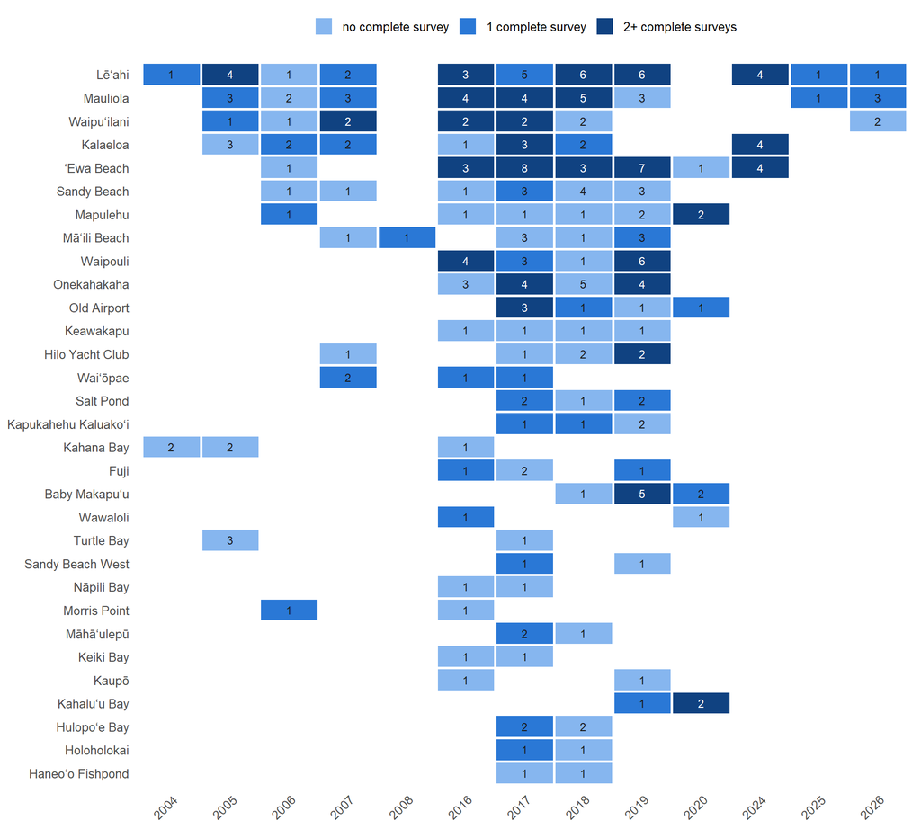

Figure 1: **Survey coverage by site and year.** Each tile is a site-year that has at least one survey. Colour shows how many surveys met the completeness rule (≥ 80% of planned quadrats, metadata present). The number is the total surveys that year. Only sites visited in two or more different years are shown. There are no files for 2009–2015 or 2021–2023.

```r
sy <- summarise_site_year(checked)
multi_year <- sy |> count(site_std) |> filter(n >= 2) |> pull(site_std)
sy |>
  filter(site_std %in% multi_year) |>
  mutate(coverage_tier = factor(coverage_tier, c("no complete survey",
                                                 "1 complete survey",
                                                 "2+ complete surveys")),
         site_std = fct_reorder(site_std, year, .fun = length),
         year = factor(year)) |>
  ggplot(aes(year, site_std, fill = coverage_tier)) +
  geom_tile(colour = "white", linewidth = 1) +
  geom_text(aes(label = n_surveys,
                colour = coverage_tier == "2+ complete surveys"), size = 3.2) +
  scale_fill_manual(values = blue, drop = FALSE, name = NULL) +
  scale_colour_manual(values = c(`FALSE` = "#1a1a1a", `TRUE` = "white"), guide = "none") +
  labs(x = NULL, y = NULL) +
  theme_minimal(base_size = 12) +
  theme(panel.grid = element_blank(), legend.position = "top",
        axis.text.x = element_text(angle = 45, hjust = 1))
ggsave("Outputs/Figures/fig1_site_year_coverage.png", width = 10, height = 9, dpi = 200, bg = "white")
```

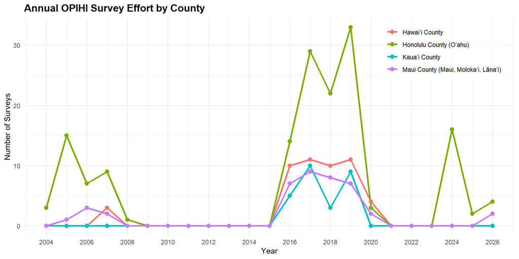

```r
county_lookup <- tribble(
  ~site_std, ~county,
  "Baby Makapuʻu", "Honolulu County (Oʻahu)",
  "Fuji", "Kauaʻi County",
  "Haneoʻo Fishpond", "Maui County (Maui, Molokaʻi, Lānaʻi)",
  "Hilo Yacht Club", "Hawaiʻi County",
  "Holoholokai", "Hawaiʻi County",
  "Hulopoʻe Bay", "Maui County (Maui, Molokaʻi, Lānaʻi)",
  "Kahaluʻu Bay", "Hawaiʻi County",
  "Kahana Bay", "Honolulu County (Oʻahu)",
  "Kalaeloa", "Honolulu County (Oʻahu)",
  "Kamaʻole II & III Beach Parks", "Maui County (Maui, Molokaʻi, Lānaʻi)",
  "Kapukahehu Kaluakoʻi", "Maui County (Maui, Molokaʻi, Lānaʻi)",
  "Kaupō", "Hawaiʻi County",
  "Keawakapu", "Maui County (Maui, Molokaʻi, Lānaʻi)",
  "Keiki Bay", "Honolulu County (Oʻahu)",
  "Keiki Ponds", "Hawaiʻi County",
  "Keʻei", "Hawaiʻi County",
  "Kona Bay Estates", "Hawaiʻi County",
  "Kīholo Bay", "Hawaiʻi County",
  "Lanikai Point", "Honolulu County (Oʻahu)",
  "Lēʻahi", "Honolulu County (Oʻahu)",
  "Mapulehu", "Maui County (Maui, Molokaʻi, Lānaʻi)",
  "Māmala Bay", "Honolulu County (Oʻahu)",
  "Mauliola", "Honolulu County (Oʻahu)",
  "Mokauea Island", "Honolulu County (Oʻahu)",
  "Morris Point", "Maui County (Maui, Molokaʻi, Lānaʻi)",
  "Moʻomomi", "Maui County (Maui, Molokaʻi, Lānaʻi)",
  "Māhāʻulepū", "Kauaʻi County",
  "Māʻili Beach", "Honolulu County (Oʻahu)",
  "Nukoliʻi", "Kauaʻi County",
  "Nāpili Bay", "Maui County (Maui, Molokaʻi, Lānaʻi)",
  "Old Airport", "Hawaiʻi County",
  "Onekahakaha", "Hawaiʻi County",
  "Oneʻo Bay", "Hawaiʻi County",
  "Punaluʻu Beach Park", "Hawaiʻi County",
  "Richardson's", "Hawaiʻi County",
  "Salt Pond", "Kauaʻi County",
  "Sandy Beach", "Honolulu County (Oʻahu)",
  "Sandy Beach West", "Honolulu County (Oʻahu)",
  "Turtle Bay", "Honolulu County (Oʻahu)",
  "Waipouli", "Kauaʻi County",
  "Waipuʻilani", "Maui County (Maui, Molokaʻi, Lānaʻi)",
  "Waiʻanae High School Reef", "Honolulu County (Oʻahu)",
  "Waiʻōpae", "Hawaiʻi County",
  "Wawaloli", "Hawaiʻi County",
  "ʻEwa Beach", "Honolulu County (Oʻahu)"
)

#Join ounty lookup tibble to checked dataset
survey_county_data <- checked |>
  left_join(county_lookup, by = "site_std")

#Group by year and county, then count # of surveys
county_counts <- survey_county_data |>
  filter(!is.na(county)) |> # Exclude unmatched sites if any exist
  group_by(year, county) |>
  summarise(n_surveys = n_distinct(survey_id), .groups = "drop")

#Fill missing year-county combinations with 0 to prevent gaps in lines
county_counts_complete <- county_counts |>
  complete(year = full_seq(year, 1), county, fill = list(n_surveys = 0))

#Plot
ggplot(county_counts_complete, aes(x = year, y = n_surveys, color = county, group = county)) +
  geom_line(linewidth = 1.2) +
  geom_point(size = 2.5) +
  scale_x_continuous(breaks = function(x) seq(floor(min(x)), ceiling(max(x)), by = 2)) +
  scale_y_continuous(limits = c(0, NA)) +
  labs(
    title = "Annual OPIHI Survey Effort by County",
    x = "Year",
    y = "Number of Surveys",
    color = NULL  # Remove legend title from aesthetic
  ) +
  theme_minimal() +
  theme(
    #Position top-right corner + inside the plot area
    legend.position = c(0.98, 0.98),
    legend.justification = c(1, 1),
    legend.direction = "vertical", #stacked
    legend.title = element_blank(),
    # Semi-transparent background --> gridlines don't clip text
    legend.background = element_rect(fill = alpha("white", 0.8), color = NA),
    plot.title = element_text(face = "bold", size = 14)
  )

#Save plot
ggsave("Outputs/Figures/county_survey.png", width = 10)
```

```r
# Fully organized code for this plot is in Outputs/Figures/Mapping_Effort.qmd

#| message: false
library(tidyverse)
library(rnaturalearth)
library(sf)
library(ggplot2)
library(plotly)
library(htmlwidgets)
library(lubridate)
library(here)

#Importing data for merging scores with lat-long, creates a gps key for site names
checked_prp <- read_csv(here("Outputs/Cleaned Data/opihi_surveys_effort.csv")) |>
  select(site_std, latitude, longitude) |>
  drop_na()|>
  group_by(across(everything()))|>
  summarise() |> #It was here ran alternate code
  #summarise(n = n())
                #in order to find our offending duplicate, which was 1 count of a 2nd Le'ahi

  ungroup() |> #you need to ungroup to drop specific row #s
  filter(!row_number() == 21) |> #removing 1 offending Le'ahi group. I think the 'okina was different between those two which is causing downstream issues
  group_by(across(everything()))

quad_master <- read_csv(here("Outputs/Cleaned Data/opihi_quadrats_master.csv"))

#joins the key for site names with lat/long!
effort_map <- left_join(quad_master,
                       checked_prp, by = "site_std",
                       ) |>
              mutate(year = year(as.Date(date))) |> #extract Years from date column, visualizing by day isn't pretty
              group_by(year, site_std) |>
              summarise(mean_year_score = mean(total_points), #averages the score across a year and site
              latitude = first(latitude), #first() reduces noise from possible joining errors, also joins the columns to keep them safe from the drop step
              longitude = first(longitude),
              .groups = "drop") |> #drop columns that aren't grouped
              filter(!is.na(latitude) & !is.na(longitude)) #remove any observations that have NAs to keep our map clean

# 1. Get polygon data for the Hawaiian Islands (WGS84 EPSG:4326)
hawaii_sf <- ne_states(country = "United States of America", returnclass = "sf") %>%
  filter(name == "Hawaii")

# Define spatial bounding box around the main Hawaiian Islands
hawaii_bbox <- c(xmin = -160.5, xmax = -154.5, ymin = 18.8, ymax = 22.5)

# 2. Build the ggplot map
p <- ggplot() +
  # Map layer: Polygon of Major Hawaiian Islands
  geom_sf(data = hawaii_sf, fill = "gray90", color = "gray50", size = 0.3) +
  # Data layer: Site dots with year frames for animation
  geom_point(
    data = effort_map,
    aes(
      x = longitude,
      y = latitude,
      fill = mean_year_score,
      frame = year,
      text = paste0(
        "Site: ", site_std, "<br>",
        "Year: ", year, "<br>",
        "Mean Score: ", round(mean_year_score, 2)
      )
    ),
    shape = 21,
    color = "black",
    size = 4,
    stroke = 0.5
  ) +
  # Color scale setup
  scale_fill_viridis_c(option = "viridis", name = "Mean Score") +
  # Restrict coordinates to the main island range
  coord_sf(
    xlim = c(hawaii_bbox["xmin"], hawaii_bbox["xmax"]),
    ylim = c(hawaii_bbox["ymin"], hawaii_bbox["ymax"]),
    expand = FALSE
  ) +
  theme_minimal() +
#mmd: brute forcing grid, tick, and label removal, we don't need to see the actual coords of sites
  theme(
    panel.grid.major = element_blank(),
    panel.grid.minor = element_blank(),
    axis.line = element_blank(),
    axis.text = element_blank(),
    axis.ticks = element_blank(),
    axis.title = element_blank(),
#mmd: filling the background with a globe-y blue
    panel.background = element_rect(fill ="#D0E6F6", color = NA),
    plot.background  = element_rect(fill = "#D0E6F6", color = NA),
  ) +
  labs(
    title = "Average Effort Across Sites"
  )

# p inspect your polygon

# 3. Convert ggplot to animated Plotly widget
widget <- ggplotly(p, tooltip = "text") %>%

#mmd: adding in a section to color the backgrounds, gotta double up on this just to be sure plotly plays nice
  layout(
    paper_bgcolor = "#D0E6F6",
    plot_bgcolor  = "#D0E6F6"
  ) |>
  animation_opts(frame = 1000, transition = 300, redraw = TRUE) %>%
  animation_slider(currentvalue = list(prefix = "Year: ", font = list(color = "black")))

# 4. Save the widget to an HTML file
saveWidget(widget, file = "hawaii_effort_map.html", selfcontained = TRUE)

widget
```

[interactive chart not shown]

These patterns are descriptive only. No statistical tests were run.

## 8. AI use

See `AI_developer_log.md`.